# Simulation Scenario B: Collider bias

One dementia cut point; quadratic time to dementia

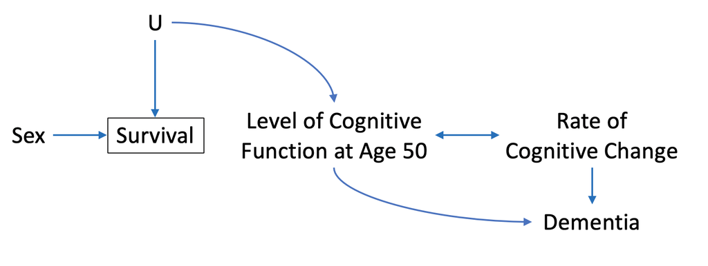

# 1 Description of Hypothetical Cohort Study

## 1.1 Survival

We are now calibrating dementia incidence to the US based ACT study[1], thus we are using US life table data. Looking at baseline age data and taking a weighted average, it seems like the 1919-1921 birth cohort is appropriate for calibration.

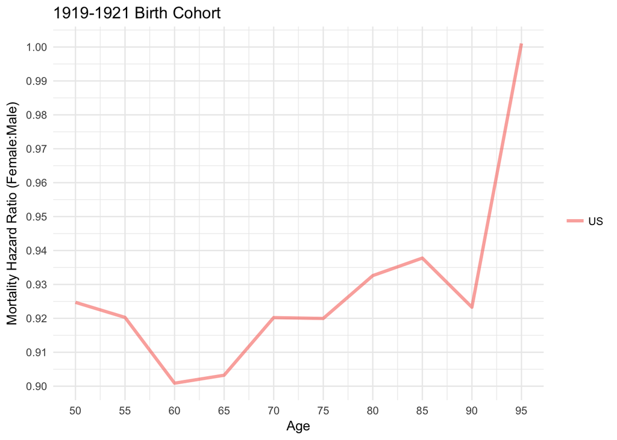

Figure 1.1: Female:Male mortality hazard ratios calculated from US life tables.

Sex-specific survival distributions from ages 50-95 years were generated to match survival distributions from the US cohort life table (1919-1921 birth cohort.) For individual $i$ in time interval $j$, time to death was generated as a random variable drawn from an exponential survival distribution based on the hazard function in Equation (1.1).

$$\begin{equation}
h_{\text{death}_{ij}}(t) = \lambda_{j}\exp\{\gamma_{1j}\text{sex}_i + \gamma_2U_i + \gamma_3\text{slope}_{ij} + \gamma_4\text{C}_{ij}\},
\tag{1.1}
\end{equation}$$

Table 1.1: Coefficients used to generate mortality hazard

|  | $\gamma_{11}$ | $\gamma_{12}$ | $\gamma_{13}$ | $\gamma_{14}$ | $\gamma_{15}$ | $\gamma_{16}$ | $\gamma_{17}$ | $\gamma_{18}$ | $\gamma_{19}$ | $\gamma_{2}$ | $\gamma_{3}$ |
| --- | --- | --- | --- | --- | --- | --- | --- | --- | --- | --- | --- |
| Simulation Scenario |  |  |  |  |  |  |  |  |  |  |  |
| A | -0.048224 | -0.125940 | -0.108922 | -0.100805 | -0.091893 | -0.119477 | -0.109389 | -0.126488 | -0.056163 | 0.693147 | 0.000000 |

Using R’s optim function [2], we solved for the $\lambda_j$ values and $\gamma_{1j}$ (baseline mortality hazard for men in each 5-year age band and the effect of sex on mortality, respectively) in our hazard function so that cumulative probabilities of survival, conditional on survival to age 50 in our simulated data closely matched those calculated from the US cohort life table.

Table 1.2 shows the computed values of $\lambda_j$ for our hazard function. Figure 1.2 compares the simulated cumulative survival probabilities from age 50 years based on these $\lambda_j$, i.e., the probability of surviving to each age conditional on survival to age 50, with cumulative survival probabilites calculated from the US life tables. Figure 1.3 compares the simulated mortality hazard ratios from ages 50+ to those calculated from life tables. Both the survival probabilities calculated from simulated data and the modeled mortality hazard ratios were averaged over 100 iterations of sample generation. The average of the mortality hazard ratios was computed by first taking the mean of the observed age-specific ln(mortality HR) across the 100 simulated samples and then exponentiating. Average cumulative mortality = 99.1% across the 100 simulated samples.

|  | Age [50-55) | [55-60) | [60-65) | [65-70) | [70-75) | [75-80) | [80-85) | [85-90) | [90-95) |
| --- | --- | --- | --- | --- | --- | --- | --- | --- | --- |
| Lambda | 0.0113 | 0.01701 | 0.02615 | 0.04223 | 0.0738 | 0.133 | 0.25018 | 0.48629 | 0.8831 |

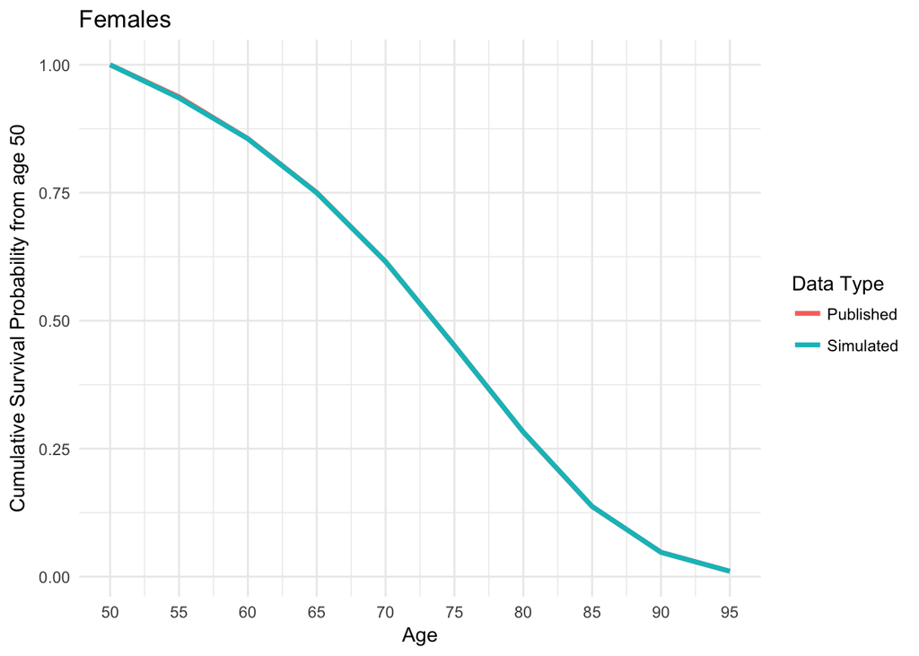

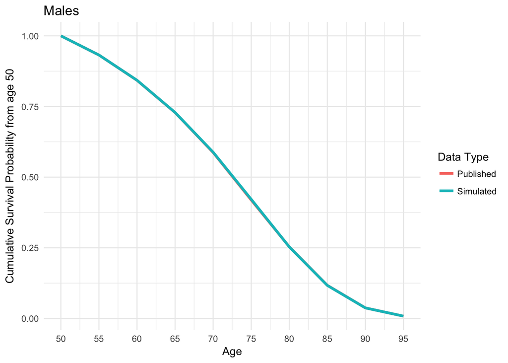

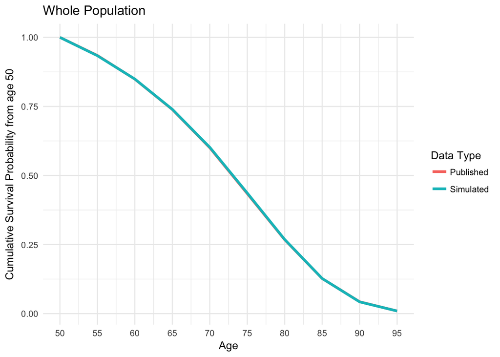

Figure 1.2: Average simulated cumulative survival probabilites from age 50 years across 100 iterations of sample generation

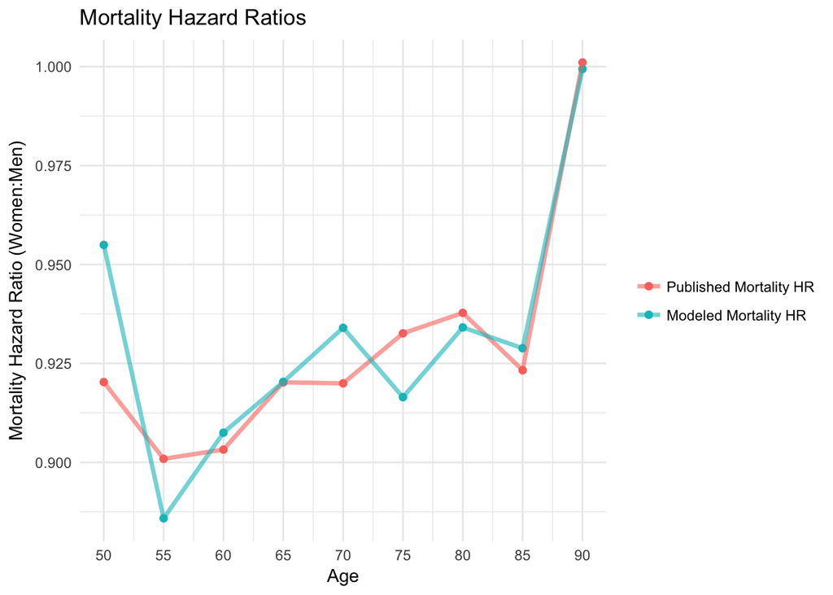

Figure 1.3: Average simulated mortality hazard ratios for age 50+ across 100 simulation runs. Ages on the x-axis represent the age at the start of interval, i.e. 50 represents the mortality HR for the interval [50, 55).

## 1.2 Survival Sanity Check Calculations

Table 1.3: Cumulative survival for women conditional on survival to age 50

|  | Age 50 | Age [50-55) | [55-60) | [60-65) | [65-70) | [70-75) | [75-80) | [80-85) | [85-90) | [90-95) |
| --- | --- | --- | --- | --- | --- | --- | --- | --- | --- | --- |
| Published | 1 | 0.93732 | 0.85581 | 0.75053 | 0.61540 | 0.45130 | 0.28240 | 0.13700 | 0.04772 | 0.01048 |
| Simulated | 1 | 0.93511 | 0.85524 | 0.74977 | 0.61544 | 0.45098 | 0.28265 | 0.13716 | 0.04741 | 0.01056 |
| Difference (Sim - Pub) | 0 | -0.00221 | -0.00057 | -0.00076 | 0.00004 | -0.00032 | 0.00025 | 0.00016 | -0.00031 | 0.00008 |

Table 1.3: Cumulative survival for men conditional on survival to age 50

|  | Age 50 | Age [50-55) | [55-60) | [60-65) | [65-70) | [70-75) | [75-80) | [80-85) | [85-90) | [90-95) |
| --- | --- | --- | --- | --- | --- | --- | --- | --- | --- | --- |
| Published | 1 | 0.93208 | 0.84255 | 0.72858 | 0.58721 | 0.41917 | 0.25355 | 0.11724 | 0.03741 | 0.00823 |
| Simulated | 1 | 0.93216 | 0.84280 | 0.72902 | 0.58827 | 0.42173 | 0.25334 | 0.11688 | 0.03728 | 0.00829 |
| Difference (Sim - Pub) | 0 | 0.00008 | 0.00024 | 0.00044 | 0.00106 | 0.00257 | -0.00021 | -0.00036 | -0.00013 | 0.00006 |

Table 1.3: HRs (Women:Men)

|  | Age [50-55) | [55-60) | [60-65) | [65-70) | [70-75) | [75-80) | [80-85) | [85-90) | [90-95) |
| --- | --- | --- | --- | --- | --- | --- | --- | --- | --- |
| Published | 0.92028 | 0.90088 | 0.90322 | 0.92022 | 0.91996 | 0.93260 | 0.93777 | 0.92328 | 1.00105 |
| Simulated | 0.95494 | 0.88584 | 0.90749 | 0.92034 | 0.93400 | 0.91647 | 0.93409 | 0.92883 | 0.99941 |
| Difference (Sim - Pub) | 0.03466 | -0.01504 | 0.00427 | 0.00011 | 0.01404 | -0.01614 | -0.00368 | 0.00555 | -0.00164 |

## 1.3 Dementia

Dementia incidence was generated based on cognitive function using an age-constant cut point for “dementia”. The model for generating $C_{ij}$ is displayed in (1.2)

$$\begin{equation}
C_{ij}(t) = \beta_{00} + \zeta_{0i} + \beta_{01}\text{sex}_i + \beta_{02}U_i + \varepsilon_{i} + (\beta_{10} + \zeta_{1i} + \beta_{11}\text{sex}_i + \beta_{12}U_i)t + (\beta_{20} + \zeta_{2i} + \beta_{21}\text{sex}_i + \beta_{22}U_i)t^2,
\tag{1.2}
\end{equation}$$

where $U_i \sim N(0,1)$. Here, $\varepsilon_{ij} \sim N(0, \sigma^2_{\varepsilon})$ represents unexplained variation in $C_{ij}$.

Time to dementia is calculated based on when the individual fell below the age-constant dementia cut point.

The chosen dementia cut point and its associated percentile for each 5-year age band are displayed in Table 1.4. Percentile values represent the proportion of the living, dementia-free cohort that will be diagnosed with dementia by the end of the time interval. There was no interval censoring included in our simulations; age at dementia diagnosis was based on the age at which a participant’s cognitive function fell below the diagnostic threshold for the 5-year age band. Age-specific dementia incidence rates for ages 65-95 were generated to match male AD incidence rates from the ACT study. The data were generated assuming no effect of sex/gender on late-life cognitive trajectories and dementia incidence, thus associations between sex/gender and dementia incidence reflect survival bias in our simulations.

Table 1.4: Dementia cut points and associated percentiles. The percentile is the proportion of susceptible that will be diagnosed with dementia.

|  | Age <50 | [50, 55) | [55-60) | [60-65) | [65-70) | [70-75) | [75-80) | [80-85) | [85-90) | [90-95) |
| --- | --- | --- | --- | --- | --- | --- | --- | --- | --- | --- |
| Dementia Cutoff | -6.5 | -6.5 | -6.5 | -6.5 | -6.50000 | -6.50000 | -6.50000 | -6.50000 | -6.50000 | -6.50000 |
| Percentile | 0.0 | 0.0 | 0.0 | 0.0 | 0.00005 | 0.00405 | 0.05675 | 0.22797 | 0.45859 | 0.64729 |

|  | Age [50-55) | [55-60) | [60-65) | [65-70) | [70-75) | [75-80) | [80-85) | [85-90) | [90-95) |
| --- | --- | --- | --- | --- | --- | --- | --- | --- | --- |
| ACT |  |  |  | 4.431 | 5.492 | 14.742 | 34.725 | 53.162 | 83.815 |
| Simulation Scenario A |  |  |  |  |  |  |  |  |  |
| F | 0.00000000 | 0.00000000 | 0.00011257 | 4.02807197 | 5.46295455 | 15.76251878 | 37.15659852 | 60.12644377 | 81.47224324 |
| M | 0.000000000 | 0.000000000 | 0.000072868 | 4.029085799 | 5.453861233 | 15.670919775 | 36.961899032 | 59.931680714 | 81.104142158 |
| Combined | 0.000000000 | 0.000000000 | 0.000093372 | 4.028521557 | 5.458598415 | 15.719543809 | 37.066807692 | 60.036659161 | 81.290839491 |

Table 1.6: Average incidence rate ratios for dementia (exponentiated mean of the observed ln(dementia IRR) across 100 simulated samples).

|  | Age [50-55) | [55-60) | [60-65) | [65-70) | [70-75) | [75-80) | [80-85) | [85-90) | [90-95) |
| --- | --- | --- | --- | --- | --- | --- | --- | --- | --- |
| Simulation Scenario A |  |  |  |  |  |  |  |  |  |
| IRR | NA | NA | NA | 0.99982 | 1.00172 | 1.00592 | 1.00529 | 1.00340 | 1.00546 |

Table 1.7: Incidence rate ratios for dementia from the ACT study

|  | [65-70) | [70-75) | [75-80) | [80-85) | [85-90) | [90-95) |
| --- | --- | --- | --- | --- | --- | --- |
| ACT |  |  |  |  |  |  |
| IRR (Women:Men) | 0.28386 | 0.98015 | 0.96508 | 1.06092 | 1.26767 | 1.08594 |

# 2 Some results from one simulated sample

## 2.1 Cognitive Trajectories

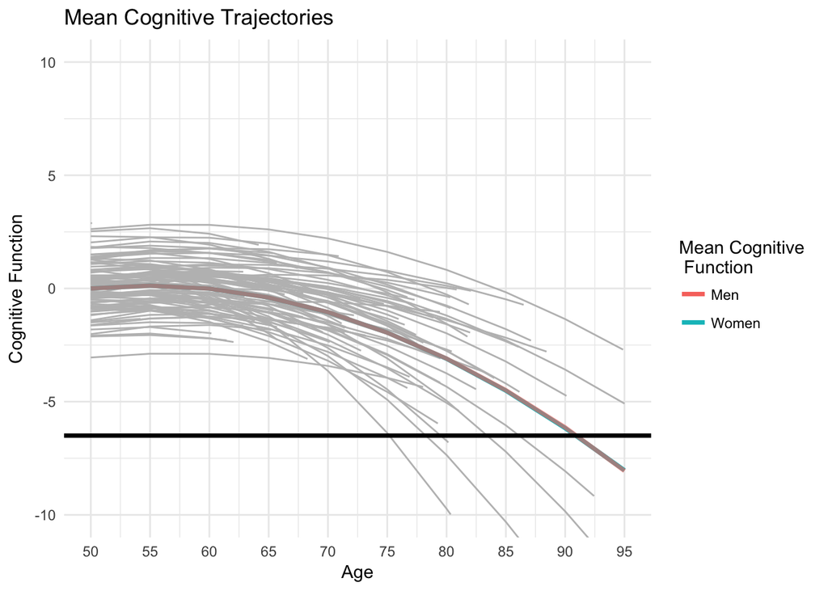

**These values will eventually just be tables in the parameters for the $C_{ij}$ model.**

## 2.2 Dementia Cases

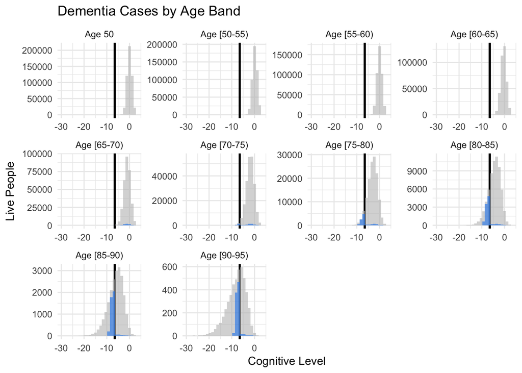

Figure 2.2: Dementia cases by age from one simulated sample. Incident cases at each age are plotted in blue. (Note that the y-axis differs across age bands because of the large difference in number of live people across age bins.)

Number of people with random/shock dementia: 17482 (0.03496)  
Number of people with trajectory dementia: 311482 (0.62296)  
Number of people with both types: 10753 (0.02151)

## 2.3 Distributions of U

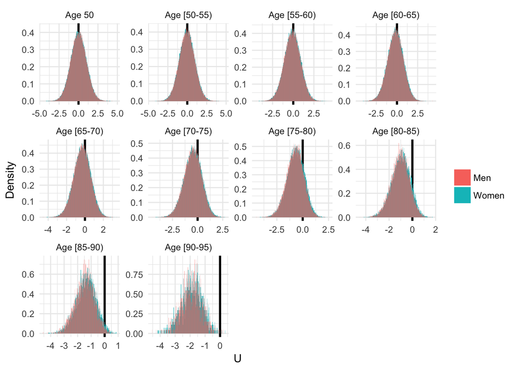

Figure 2.3: Distribution of U by age and sex/gender in one simulated sample.

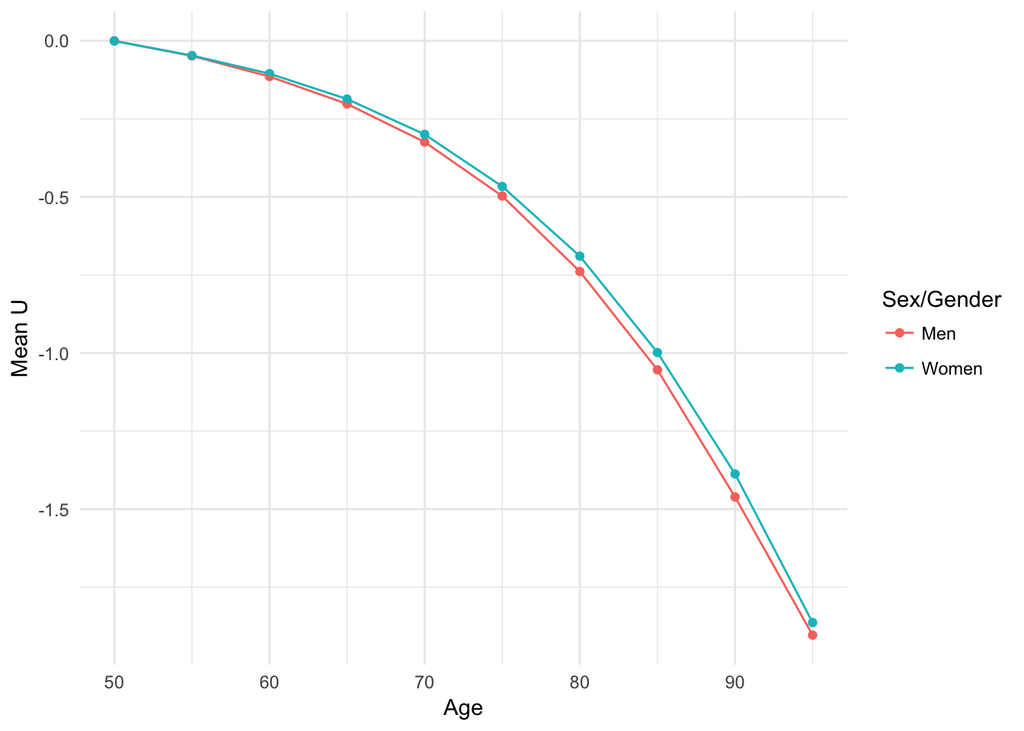

## 2.4 Extra Sanity Check Calculations

Table 2.1: Dementia-free person-years contributed to each 5-year age interval by sex from one simulated sample.

| Sex | Age [50-55) | [55-60) | [60-65) | [65-70) | [70-75) | [75-80) | [80-85) | [85-90) | [90-95) |
| --- | --- | --- | --- | --- | --- | --- | --- | --- | --- |
| Male | 1181854 | 1084853 | 959785 | 794345 | 591465 | 371248 | 173315 | 53773 | 10586 |
| Female | 1233611 | 1140887 | 1022351 | 859352 | 652879 | 423283 | 207077 | 68571 | 14128 |

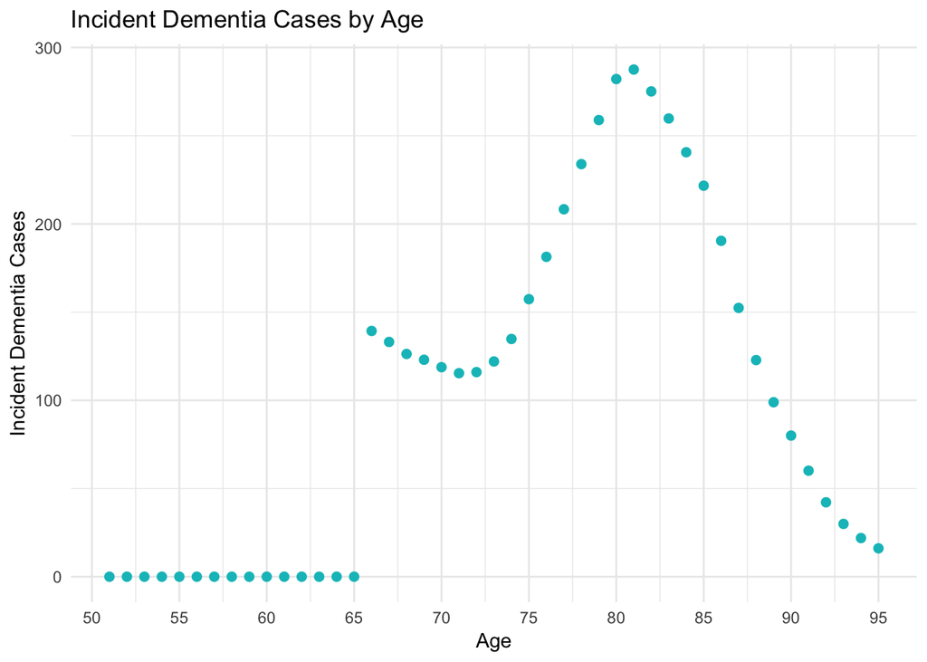

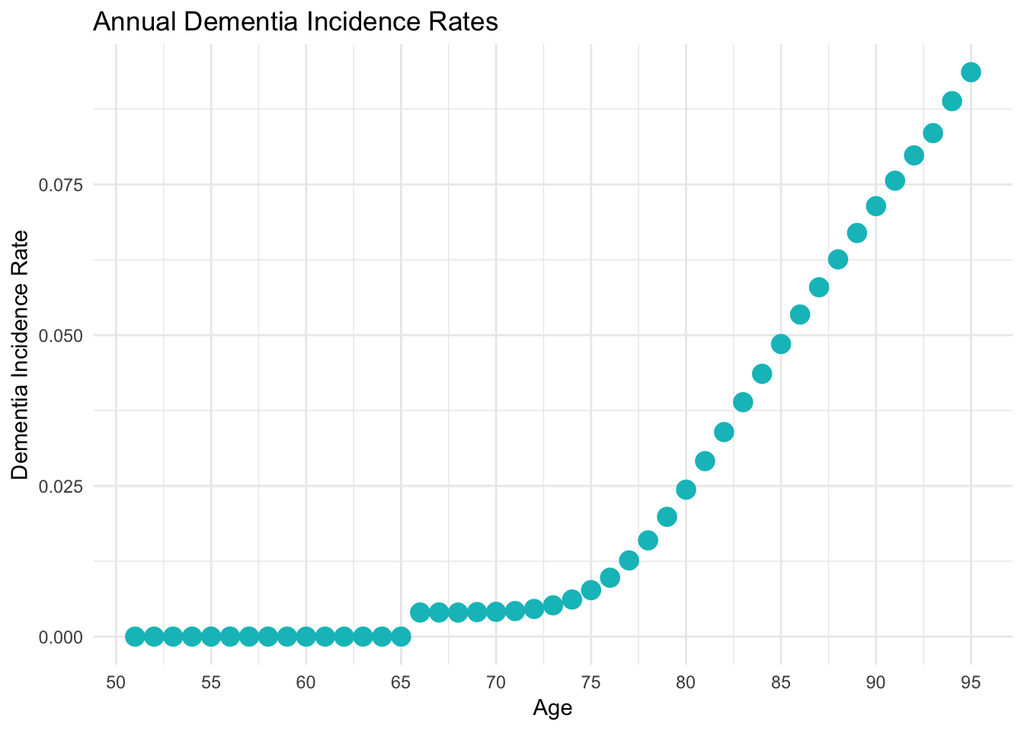

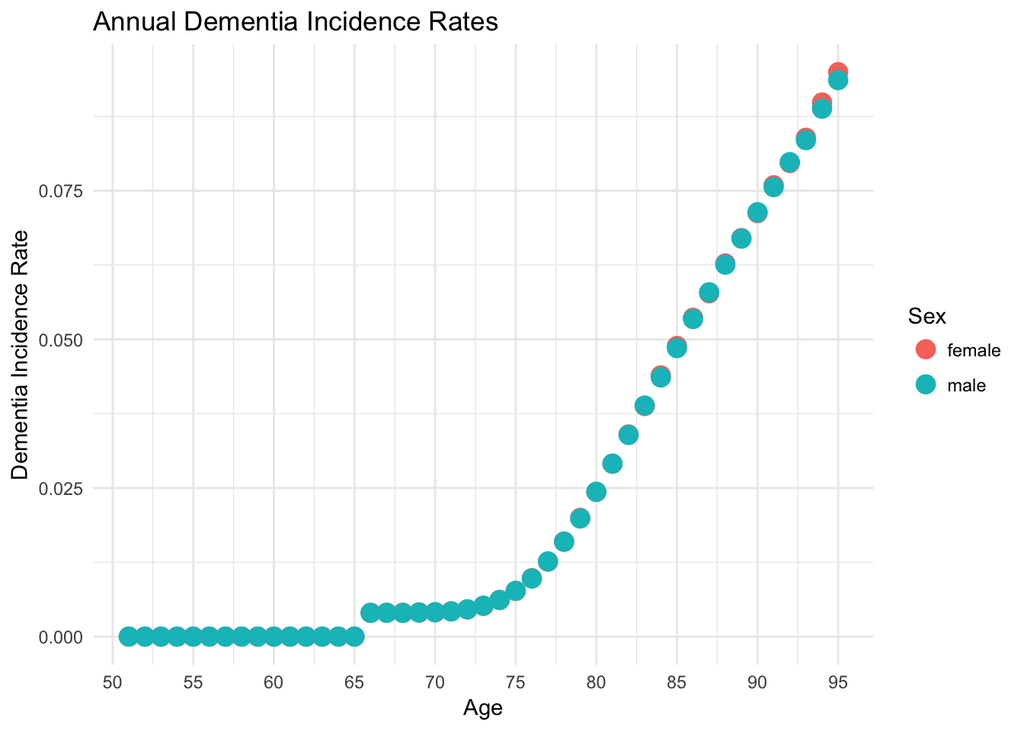

# References

[1] S. Tom *et al.*, “Characterization of Dementia and Alzheimer’s Disease in an Older Population: Updated Incidence and Life Expectancy With and Without Dementia,” *Am J Public Health*, vol. 105, no. 2, pp. 408–414, 2015.

[2] R Core Team, “R: A language and environment for statistical computing.” R Foundation for Statistical Computing, Vienna, Austria, 2017 [Online]. Available: https://www.R-project.org/